# Will Chase Young be an All-Pro Player: A Python Tutorial

## Background

As a fan of the NFL's Washington Football Team, I have become accustomed to disappointment. Year after year, we have been let down by the team. Washington has simply not been a place for greatness since the early 1990s. However, in 2020, fans were given a ray of hope. His name was Chase Young. The rookie defensive lineman exploded onto the NFL scene, racking up highlights all over the field and earning Defensive Rookie of the Year honors. Now people are calling him an early contender for overall Defensive Player of the Year for the 2021 season. As a fan, all this hype gets me very excited, but as a *Washington* fan, I know better than to assume these lofty projections will actually come true. In order to properly weigh the validity of these expectations, we will analyze NFL defensive player statistics, and discover trends to project whether a player will become a star based on their play in seasons past.

In sum, the goal of this tutorial is to predict Chase Young's statistics for his best season, then see if those statistics would be good enough to earn him all-pro honors. Formally, our null hypothesis is that Chase Young will never be an all-pro player. Let's hope we prove that wrong.

## Libraries

For many python projects, it helps to import libraries of already written python objects and methods. For this project, we will use several libraries to help us in managing and plotting data. [BeautifulSoup](https://www.crummy.com/software/BeautifulSoup/bs4/doc/) and [Requests](https://docs.python-requests.org/en/master/) will help us pull data from the internet, [Pandas](https://pandas.pydata.org/docs/) and [Numpy](https://numpy.org/doc/stable/) will help with creating and managing the data tables, [pyplot](https://matplotlib.org/stable/api/_as_gen/matplotlib.pyplot.html) makes plotting the data easier, and [sklearn](https://scikit-learn.org/stable/user_guide.html) provides the tolls for creating predictive algorithms.

```python
from bs4 import BeautifulSoup
import requests as reqs

import pandas as pd
import numpy as np

import matplotlib.pyplot as plt

from sklearn import linear_model
import statsmodels.api as sm
from sklearn.tree import DecisionTreeClassifier
import sklearn.model_selection as ms
import sklearn.metrics as met
```

## Part 1: Gather Data

### The Data

We will use data collected by Pro Football Reference. The site keeps detailed records of game, season, and player stats from most of the league's 100 year existance. We will focus on defensive player statistics from the 2006-2020 seasons. We are starting at 2006 because that was the year the NFL started recording a new statistic, "Quarterback Hits," which may help us better predict the success of pass rushers.

Unfortunately, Pro Football Reference releases its information in yearly tables, so we will need to pull data for each year individually, then merge them into one single table to use for the rest of the tutorial. First, we will go through the step-by-step process of scraping the data from the site and formatting it to fit our needs for just the 2006 season, then we will loop through the rest of the years to complete our table.

Source: https://www.pro-football-reference.com/years/2020/defense.htm

### Step 1: Data Scraping

First, we pull the data from the html page using requests. We then use BeautifulSoup to format the scraped data. Finally, we turn the data into a pandas DataFrame.

#### a) Scrape the data from the html page

```python
url = "https://www.pro-football-reference.com/years/2006/defense.htm"

page = reqs.get(url)
soup = BeautifulSoup(page.text)
```

#### b) Use BeautifulSoup to format the table

The soup_table object is the list of tables we scraped from the page. As shown below, there is only one table stored in this list. Therefore, we know this one table is what we are after. We can now pull the table stored in index 0 of our soup_table object.

```python
soup_table = soup.findAll('table')
print("Number of tables found in HTML:", len(soup_table))
```

```
Number of tables found in HTML: 1
```

#### c) Convert the data into a Pandas DataFrame

```python
table = pd.read_html(str(soup_table[0]))[0]
```

```python
table.head()
```

|  | Unnamed: 0_level_0 Rk | Unnamed: 1_level_0 Player | Unnamed: 2_level_0 Tm | Unnamed: 3_level_0 Age | Unnamed: 4_level_0 Pos | Games G | Games GS | Def Interceptions Int | Def Interceptions Yds | Def Interceptions TD | ... | Fumbles FR | Fumbles Yds | Fumbles TD | Unnamed: 17_level_0 Sk | Tackles Comb | Tackles Solo | Tackles Ast | Tackles TFL | Tackles QBHits | Unnamed: 23_level_0 Sfty |
| --- | --- | --- | --- | --- | --- | --- | --- | --- | --- | --- | --- | --- | --- | --- | --- | --- | --- | --- | --- | --- | --- |
| 0 | 1 | DeMeco Ryans | HOU | 22 | MLB | 16 | 16 | 1 | 16 | 0 | ... | 1 | 0 | 0 | 3.5 | 156 | 126 | 30 | 13 | 9 | NaN |
| 1 | 2 | Lance Briggs* | CHI | 26 | RLB | 16 | 16 | 2 | 18 | 0 | ... | 1 | 0 | 0 | 1.0 | 134 | 113 | 21 | 11 | 2 | NaN |
| 2 | 3 | Antonio Pierce* | NYG | 28 | MLB | 16 | 16 | 1 | 6 | 0 | ... | 2 | 0 | 0 | 1.0 | 139 | 109 | 30 | 10 | 3 | NaN |
| 3 | 4 | Zach Thomas*+ | MIA | 33 | MLB | 16 | 16 | 1 | -4 | 0 | ... | 0 | 0 | 0 | 3.0 | 165 | 103 | 62 | 7 | 3 | NaN |
| 4 | 5 | Kirk Morrison | OAK | 24 | MLB | 16 | 16 | 2 | 32 | 0 | ... | 1 | 35 | 1 | 1.0 | 128 | 102 | 26 | 14 | 1 | NaN |

5 rows × 24 columns

### Step 2: Tidy the DataFrame

We now have our data (for 2006 at least). However, there is a lot to change about the way the table is currently formatted before we can use it to make any real observations. In this section we will edit the table to make it not only work the way we want, but hold only the information that is important to us.

#### a) Format the columns

Notice above that the Column headings are multi-level. We want the column headings to be a single row to make it easier to both pull and add columns. To do this, we change the format of the columns to a list. Just to be safe, we do the same with the index.

```python
table.index = list(table.index)
table.columns = list(table.columns)
table.head()
```

|  | (Unnamed: 0_level_0, Rk) | (Unnamed: 1_level_0, Player) | (Unnamed: 2_level_0, Tm) | (Unnamed: 3_level_0, Age) | (Unnamed: 4_level_0, Pos) | (Games, G) | (Games, GS) | (Def Interceptions, Int) | (Def Interceptions, Yds) | (Def Interceptions, TD) | ... | (Fumbles, FR) | (Fumbles, Yds) | (Fumbles, TD) | (Unnamed: 17_level_0, Sk) | (Tackles, Comb) | (Tackles, Solo) | (Tackles, Ast) | (Tackles, TFL) | (Tackles, QBHits) | (Unnamed: 23_level_0, Sfty) |
| --- | --- | --- | --- | --- | --- | --- | --- | --- | --- | --- | --- | --- | --- | --- | --- | --- | --- | --- | --- | --- | --- |
| 0 | 1 | DeMeco Ryans | HOU | 22 | MLB | 16 | 16 | 1 | 16 | 0 | ... | 1 | 0 | 0 | 3.5 | 156 | 126 | 30 | 13 | 9 | NaN |
| 1 | 2 | Lance Briggs* | CHI | 26 | RLB | 16 | 16 | 2 | 18 | 0 | ... | 1 | 0 | 0 | 1.0 | 134 | 113 | 21 | 11 | 2 | NaN |
| 2 | 3 | Antonio Pierce* | NYG | 28 | MLB | 16 | 16 | 1 | 6 | 0 | ... | 2 | 0 | 0 | 1.0 | 139 | 109 | 30 | 10 | 3 | NaN |
| 3 | 4 | Zach Thomas*+ | MIA | 33 | MLB | 16 | 16 | 1 | -4 | 0 | ... | 0 | 0 | 0 | 3.0 | 165 | 103 | 62 | 7 | 3 | NaN |
| 4 | 5 | Kirk Morrison | OAK | 24 | MLB | 16 | 16 | 2 | 32 | 0 | ... | 1 | 35 | 1 | 1.0 | 128 | 102 | 26 | 14 | 1 | NaN |

5 rows × 24 columns

While the columns are now all one line, they are stored as a Tuple-- an object that stores two values--rather than a single string. Additionally, several of them hold an unnecessary **"Unnamed: ..."** string in their title. Our job now is to join the strings in each tuple together while eliminating the unnecessary strings.

```python
table.columns = [name[1] if "Unnamed" in name[0] else name[0] + "_" + name[1] for name in table.columns]
table.head()
```

|  | Rk | Player | Tm | Age | Pos | Games_G | Games_GS | Def Interceptions_Int | Def Interceptions_Yds | Def Interceptions_TD | ... | Fumbles_FR | Fumbles_Yds | Fumbles_TD | Sk | Tackles_Comb | Tackles_Solo | Tackles_Ast | Tackles_TFL | Tackles_QBHits | Sfty |
| --- | --- | --- | --- | --- | --- | --- | --- | --- | --- | --- | --- | --- | --- | --- | --- | --- | --- | --- | --- | --- | --- |
| 0 | 1 | DeMeco Ryans | HOU | 22 | MLB | 16 | 16 | 1 | 16 | 0 | ... | 1 | 0 | 0 | 3.5 | 156 | 126 | 30 | 13 | 9 | NaN |
| 1 | 2 | Lance Briggs* | CHI | 26 | RLB | 16 | 16 | 2 | 18 | 0 | ... | 1 | 0 | 0 | 1.0 | 134 | 113 | 21 | 11 | 2 | NaN |
| 2 | 3 | Antonio Pierce* | NYG | 28 | MLB | 16 | 16 | 1 | 6 | 0 | ... | 2 | 0 | 0 | 1.0 | 139 | 109 | 30 | 10 | 3 | NaN |
| 3 | 4 | Zach Thomas*+ | MIA | 33 | MLB | 16 | 16 | 1 | -4 | 0 | ... | 0 | 0 | 0 | 3.0 | 165 | 103 | 62 | 7 | 3 | NaN |
| 4 | 5 | Kirk Morrison | OAK | 24 | MLB | 16 | 16 | 2 | 32 | 0 | ... | 1 | 35 | 1 | 1.0 | 128 | 102 | 26 | 14 | 1 | NaN |

5 rows × 24 columns

#### b) Keep only useful data

Our table is ready to be modified now that the columns are properly formatted. First, we will start erasing data that is not important to us. Our focus is on projecting the success of Chase Young, so we only need to look at players who do what he does on the field. That means we can erase every player that is not a pass rusher (Chase Young is a pass rusher).

First, take a look at the positions stored in the table. One thing stands out: some are uppercase, and some are lowercase. Before we can erase the positions we don't want, we need to make the format universal. To do this, set all the strings stored in the column to uppercase.

```python
print(table['Pos'].unique())
```

```
['MLB' 'RLB' 'RILB' 'SS' 'FS' 'LLB' 'RCB' 'LILB' 'LCB' 'Pos' 'rcb' 'mlb'
 'RDE' 'LDE' 'ROLB' 'fs' 'ss' nan 'RDT' 'lcb' 'LOLB' 'rlb' 'NT' 'rilb'
 'rde' 'llb' 'LDT' 'rolb' 'lde' 'rdt' 'cb' 'lolb' 'ldt' 'FB' 'te' 'fb'
 'WR' 'wr' 'TE' 'LT' 'rb' 'RB' 'LG' 'RG' 'c' 'RT' 'C' 'QB' 'qb' 'lg' 'rg'
 'rt']
```

```python
table['Pos'] = [str(pos).upper() for pos in table['Pos']]
```

Now that the positions are universally formatted, we can identify and pull the correct positions from the table. Positions that typically focus on rushing the passer are: Oustide Linebackers (OLB), Defensive Ends (LB), and Defensive Tackles (DT).

Make a list of all positions stored in the table fitting one of those titles.

```python
positions = []
for pos in table['Pos'].unique():
    if  "DT" in pos or "OLB" in pos or "DE" in pos:
        positions.append(pos)

positions
```

```
['RDE', 'LDE', 'ROLB', 'RDT', 'LOLB', 'LDT']
```

Now that we are cutting the table down to just the positions we care about, we will start using a new table: "linemen." We are going iterate through the list of acceptable positions we just made and put all rows from the original table that match these positions into the new linemen table.

```python
linemen = table.loc[table['Pos'] == positions[0]]
for i in range(1, len(positions)):
    linemen = linemen.append(table.loc[table['Pos'] == positions[i]])
```

Just as we only want to look at players comparable to Chase Young, we also only want to look at the statistics that are important to players of his position. For our study, we will use age, position, games started, sacks, QB hits, and total tackles. We will also keep player names to help us identify Chase Young in future plots.

```python
linemen = linemen[['Player','Age','Pos','Games_G','Games_GS','Sk','Tackles_Comb','Tackles_QBHits']]
```

Another wrinkle in the formatting of the data is that the numbers stored in the frame are not actually numbers. They're strings! To fix this, we can call the **to_numeric** function on all comumns that should hold numbers to convert them to usable numbers.

```python
linemen[['Age','Games_G','Games_GS','Sk','Tackles_Comb',
         'Tackles_QBHits']] = linemen[['Age','Games_G','Games_GS','Sk',
                                       'Tackles_Comb','Tackles_QBHits']].apply(pd.to_numeric)
```

Our final piece in cutting down the table is to make sure we are looking at players who regularly see the field. We do not want our averages and/or projectections to be weighed down by someone who only played one snap all season long. Therefore, we are only going to keep data for players that started at least half of the games in a season. Since a season is 16 games long, they needed to have played for at least 8 games.

```python
linemen = linemen.loc[linemen['Games_GS'] >= 8]
linemen = linemen.reset_index(drop=True)
linemen.head()
```

|  | Player | Age | Pos | Games_G | Games_GS | Sk | Tackles_Comb | Tackles_QBHits |
| --- | --- | --- | --- | --- | --- | --- | --- | --- |
| 0 | Jared Allen | 24 | RDE | 16 | 16 | 7.5 | 76 | 15 |
| 1 | Bryan Thomas | 27 | RDE | 16 | 16 | 8.5 | 77 | 12 |
| 2 | Justin Smith | 27 | RDE | 16 | 16 | 7.5 | 80 | 19 |
| 3 | Ebenezer Ekuban | 30 | RDE | 15 | 15 | 7.0 | 63 | 10 |
| 4 | Andre Carter | 27 | RDE | 16 | 16 | 6.0 | 56 | 14 |

#### c) Standardize the data

There is a simple truth to the numbers we are looking at: a player who played 8 games will have a lower number in any catagory to an equally-skilled player who played 16. Therefore we need to standardize the numbers in the columns by making them all projections for how a 16 game season would have looked for these players. We will do this by multiplying each value by (16 / games played) for each row.

```python
standardized_sacks = []
standardized_tackles = []
standardized_QB_hits = []
for i in range(len(linemen)):
    standardized_sacks.append(linemen.at[i, 'Sk'] * (16 / linemen.at[i, 'Games_G']))
    standardized_tackles.append(linemen.at[i, 'Tackles_Comb'] * (16 / linemen.at[i, 'Games_G']))
    standardized_QB_hits.append(linemen.at[i, 'Tackles_QBHits'] * (16 / linemen.at[i, 'Games_G']))

linemen['Sk'] = standardized_sacks
linemen['Tackles_Comb'] = standardized_tackles
linemen['Tackles_QBHits'] = standardized_QB_hits
```

We can now drop the games played and started columns.

```python
linemen = linemen.drop(columns=['Games_G','Games_GS'])
linemen.head()
```

|  | Player | Age | Pos | Sk | Tackles_Comb | Tackles_QBHits |
| --- | --- | --- | --- | --- | --- | --- |
| 0 | Jared Allen | 24 | RDE | 7.500000 | 76.0 | 15.000000 |
| 1 | Bryan Thomas | 27 | RDE | 8.500000 | 77.0 | 12.000000 |
| 2 | Justin Smith | 27 | RDE | 7.500000 | 80.0 | 19.000000 |
| 3 | Ebenezer Ekuban | 30 | RDE | 7.466667 | 67.2 | 10.666667 |
| 4 | Andre Carter | 27 | RDE | 6.000000 | 56.0 | 14.000000 |

#### d) Add information to the table

Our table is looking good! Now that the information already stored is properly formatted, we can start adding columns to hold details on the rows that are not already stored in a reachable format. The information we want to add is: the year the row's data occurred, whether the player in the row made the pro bowl, and whether the player was an "all-pro" that season (an all-pro is a player deemed the very best at their position for the season).

The year is whatever year's data we are looking at, so all rows get "2006" for that column. Pro bowl and all pro designations are actually stored in the table already, under the Player column. If a player's name has an **"*"** next to it, they made the pro bowl. If there is a **"+,"** then they were an all-pro.

Iterate through each row in the column, recording in lists what should be placed in the respective columns for each row (for year, it's the year; for pro bowl and all-pro, it's a "1" if they are, and a "0" otherwise), then add these lists as columns in the DataFrame.

```python
year_list = []
made_pro_bowl = []
made_all_pro = []
for i in range(len(linemen)):
    year_list.append(2006)
    if "*" in linemen.at[i, 'Player']:
        made_pro_bowl.append(1)
    else:
        made_pro_bowl.append(0)

    if "+" in linemen.at[i, 'Player']:
        made_all_pro.append(1)
    else:
        made_all_pro.append(0)
```

```python
linemen['year'] = year_list
linemen['made_pro_bowl'] = made_pro_bowl
linemen['made_all_pro'] = made_all_pro
```

Now that we have moved the information stored in the special symbols from the player column to their own column, let's get rid of them to tidy up player names.

```python
linemen['Player'] = [cur_name.split("*")[0].strip() for cur_name in linemen['Player']]
linemen['Player'] = [cur_name.split("+")[0].strip() for cur_name in linemen['Player']]
```

#### e) Add data from current year to master table

This year's table is complete! Now we save the table under the new name "player_stats."

```python
player_stats = linemen
player_stats.head()
```

|  | Player | Age | Pos | Sk | Tackles_Comb | Tackles_QBHits | year | made_pro_bowl | made_all_pro |
| --- | --- | --- | --- | --- | --- | --- | --- | --- | --- |
| 0 | Jared Allen | 24 | RDE | 7.500000 | 76.0 | 15.000000 | 2006 | 0 | 0 |
| 1 | Bryan Thomas | 27 | RDE | 8.500000 | 77.0 | 12.000000 | 2006 | 0 | 0 |
| 2 | Justin Smith | 27 | RDE | 7.500000 | 80.0 | 19.000000 | 2006 | 0 | 0 |
| 3 | Ebenezer Ekuban | 30 | RDE | 7.466667 | 67.2 | 10.666667 | 2006 | 0 | 0 |
| 4 | Andre Carter | 27 | RDE | 6.000000 | 56.0 | 14.000000 | 2006 | 0 | 0 |

#### f) Repeat steps a-d for the 2007-2020 data

As the above table is only the data for one year, we will need to do all the work over again for the other years. Each time we complete a cycle, the DataFrame for the current year will be appended to the master table, player_stats.

```python
for cur_year in range(2007,2021):
    # Step a)
    url = "https://www.pro-football-reference.com/years/" + str(cur_year) + "/defense.htm"
    page = reqs.get(url)
    soup = BeautifulSoup(page.text)
    soup_table = soup.findAll('table')[0]
    table = pd.read_html(str(soup_table))[0]

    # Step b)
    table.index = list(table.index)
    table.columns = list(table.columns)
    table.columns = [name[1] if "Unnamed" in name[0] else name[0] + "_" + name[1] for name in table.columns]
    table['Pos'] = [str(pos).upper() for pos in table['Pos']]

    linemen = table.loc[table['Pos'] == positions[0]]
    for i in range(1, len(positions)):
        linemen = linemen.append(table.loc[table['Pos'] == positions[i]])

    linemen = linemen[['Player','Age','Pos','Games_G','Games_GS','Sk','Tackles_Comb','Tackles_QBHits']]

    linemen[['Age','Games_G','Games_GS','Sk','Tackles_Comb',
         'Tackles_QBHits']] = linemen[['Age','Games_G','Games_GS','Sk',
                                       'Tackles_Comb','Tackles_QBHits']].apply(pd.to_numeric)

    linemen = linemen.loc[linemen['Games_GS'] >= 8]
    linemen = linemen.reset_index(drop=True)

    # Step c)
    standardized_sacks = []
    standardized_tackles = []
    standardized_QB_hits = []
    for i in range(len(linemen)):
        standardized_sacks.append(linemen.at[i, 'Sk'] * (16 / linemen.at[i, 'Games_G']))
        standardized_tackles.append(linemen.at[i, 'Tackles_Comb'] * (16 / linemen.at[i, 'Games_G']))
        standardized_QB_hits.append(linemen.at[i, 'Tackles_QBHits'] * (16 / linemen.at[i, 'Games_G']))

    linemen['Sk'] = standardized_sacks
    linemen['Tackles_Comb'] = standardized_tackles
    linemen['Tackles_QBHits'] = standardized_QB_hits
    linemen = linemen.drop(columns=['Games_G','Games_GS'])

    # Step d)
    year_list = []
    made_pro_bowl = []
    made_all_pro = []
    for i in range(len(linemen)):
        year_list.append(cur_year)
        if "*" in linemen.at[i, 'Player']:
            made_pro_bowl.append(1)
        else:
            made_pro_bowl.append(0)

        if "+" in linemen.at[i, 'Player']:
            made_all_pro.append(1)
        else:
            made_all_pro.append(0)

    linemen['year'] = year_list
    linemen['made_pro_bowl'] = made_pro_bowl
    linemen['made_all_pro'] = made_all_pro

    linemen['Player'] = [cur_name.split("*")[0].strip() for cur_name in linemen['Player']]
    linemen['Player'] = [cur_name.split("+")[0].strip() for cur_name in linemen['Player']]

    # Step e)
    player_stats = player_stats.append(linemen)
```

```python
player_stats = player_stats.reset_index(drop=True)
```

#### Finished!

For a final reference, here are the descriptions of each column:

- **Player:** Player name
- **Age:** Age of the player
- **Pos:** Player position
- **Sk:** Number of sacks recorded by player
- **Tackles_Comb:** Total number of tackles by the player
- **Tackles_QBHits:** Number of times the defender made contact with the Quarterback during a passing play
- **Year:** Year the data occurred
- **made_pro_bowl:** 1 if the player made the pro bowl in given season, 0 otherwise
- **made_all_pro:** 1 if the player made the all-pro team in given season, 0 otherwise

```python
player_stats.head()
```

|  | Player | Age | Pos | Sk | Tackles_Comb | Tackles_QBHits | year | made_pro_bowl | made_all_pro |
| --- | --- | --- | --- | --- | --- | --- | --- | --- | --- |
| 0 | Jared Allen | 24 | RDE | 7.500000 | 76.0 | 15.000000 | 2006 | 0 | 0 |
| 1 | Bryan Thomas | 27 | RDE | 8.500000 | 77.0 | 12.000000 | 2006 | 0 | 0 |
| 2 | Justin Smith | 27 | RDE | 7.500000 | 80.0 | 19.000000 | 2006 | 0 | 0 |
| 3 | Ebenezer Ekuban | 30 | RDE | 7.466667 | 67.2 | 10.666667 | 2006 | 0 | 0 |
| 4 | Andre Carter | 27 | RDE | 6.000000 | 56.0 | 14.000000 | 2006 | 0 | 0 |

## Part 2: Data Visualization

### Observations to make

Before we begin making any predictions from the data, we need to gain a better understanding of what the data says. That means visualizing the data through graphs and plots.

Trends following statistics are what we need to observe:

- Sacks
- Qb Hits
- Total Tackles

We need to see how the above stastics are affected by the following categories:

- Year
- Player Age
- Position Played

Lets get to work!

#### Bonus step: Isolate Chase Young

It might be useful to see where Chase Young falls on some of these charts, so let's isolate his statistics for safe keeping in case it could be useful later.

```python
chase_young = player_stats.loc["Chase Young" == player_stats['Player']]
chase_young
```

|  | Player | Age | Pos | Sk | Tackles_Comb | Tackles_QBHits | year | made_pro_bowl | made_all_pro |
| --- | --- | --- | --- | --- | --- | --- | --- | --- | --- |
| 1235 | Chase Young | 21 | LDE | 8.0 | 46.933333 | 12.8 | 2020 | 1 | 0 |

### Step 1: Observations By Position

The first category we are going to observe is Position type. While all positions are pass-rushing groups, we do not know if the data we are looking at varies strongly between the different types of pass rushers. To determine any difference in the distribution of values for sacks, QB hits, and total tackles between the positions, we will use a violin plot. A violin plot is an object where the wider its body, the higher the number of values at that spot in the y-axis. It also tells us the mean, max, and min of the data.

#### a) Isolate important data

For this section we only need the data regarding our independent variable (position), and our dependent variables (Sacks, tackles, and QB hits).

```python
position_stats = player_stats[['Pos','Sk','Tackles_Comb','Tackles_QBHits']]
```

#### b) Reformat data to prepare for plotting

In order to create violin plots, our data needs to be formatted to fit the required inputs. To do so, we must follow these steps:

1. Group the data by position.
2. Convert each column in the DataFrame into lists of lists, where each sublist is the column for its corresponding position group.

```python
# Step 1: Group the data by position
position_data = position_stats.groupby('Pos')
```

```python
# Step 2: Convert each column in the DataFrame into lists of lists,
# where each sublist is the column for its corresponding position group

# Initializing the rows of rows
Sacks_by_pos = []
Tackles_by_pos = []
QB_hits_by_pos = []
positions = []

# Loop through each group and add each column to the corresponding list of lists
for pos, group in position_data:
    positions.append(pos)
    Sacks_by_pos.append([x for x in group['Sk'].tolist() if str(x) != 'nan'])
    Tackles_by_pos.append([x for x in group['Tackles_Comb'].tolist() if str(x) != 'nan'])
    QB_hits_by_pos.append([x for x in group['Tackles_QBHits'].tolist() if str(x) != 'nan'])

# Put these lists of lists in one big list to make it easy to call them in a loop for plotting
stats_by_pos = [Sacks_by_pos,Tackles_by_pos,QB_hits_by_pos]
stat_names = ["Sacks","Total Tackles","QB Hits"]
```

#### c) Plot data

Now we create our plots. We are going to create one plot for each of our three dependent variables, so we will loop through the plot-making steps three times.

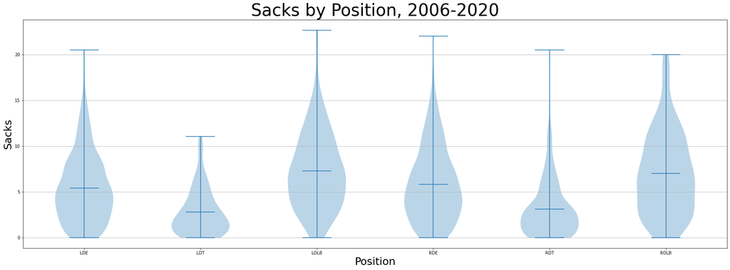

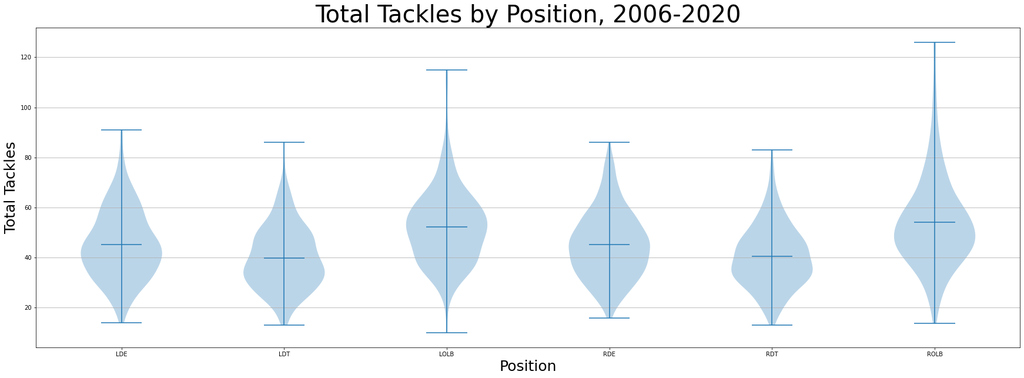

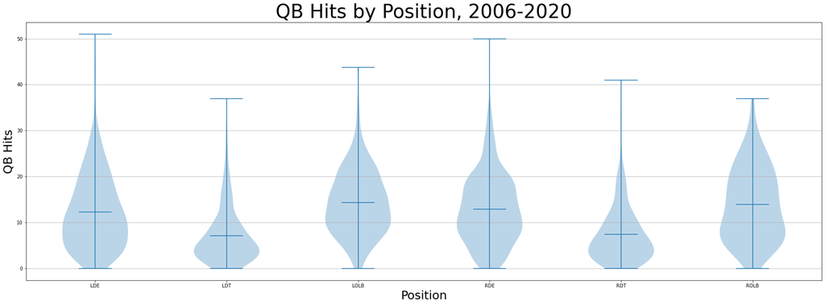

```python
for i in range(3):
    fig, ax = plt.subplots(figsize=(30, 10))
    cur_stat = stat_names[i]

    X = positions
    Y = stats_by_pos[i]
    title = cur_stat + " by Position, 2006-2020"

    ax.violinplot(Y,showmeans=True)
    ax.set_xlabel("Position",fontsize=25)
    ax.set_ylabel(cur_stat,fontsize=25)
    ax.set_title(title,fontsize=40)
    plt.grid(axis='y')

    ax.set_xticks(np.arange(1, len(positions) + 1))
    ax.set_xticklabels(positions)
```

#### d) Analysis

The plots above show that two position groups stood out from the rest: left and right defensive tackles. In all three categories, their mean values and largest points of concentration were much lower than the other positions. As Chase Young is a defensive end, and we want our predictive models to be most accurate for him specifically, we should remove defensive tackles from our data, as they would bring down the value of any model we would make in the future.

```python
player_stats = player_stats[player_stats.Pos != "RDT"]
player_stats = player_stats[player_stats.Pos != "LDT"].reset_index(drop=True)
```

### Step 2: Observations over time

The next category we will look at is year. We want our predictors for future seasons to be as accurate as possible, so having data from many seasons will give us more inputs to improve predictive accuracy. However, what if the way the game is played has changed in the last 15 years and the numbers pass-rushers were putting up in 2006 are substancially different than 2020? To measure the change in these statistics over time, we can use a line plot.

#### a) Isolate Necessary Data

For this section we only need the data regarding our independent variable (year), and our dependent variables (Sacks, tackles, and QB hits).

```python
yearly_data = player_stats[['year','Sk','Tackles_Comb','Tackles_QBHits']]
```

#### b) Reformat data to prepare for plotting

For this plot, we are going to look at mean values rather than all the points at once. There are too many players to each have as one line each in a plot, so looking at the average should make it easier for us to draw conclusions. Additionally, as we want to gain an understanding of general trends in the data over time, the mean will be particualrly useful for us.

To format the data to fit our needs, we need to first group the data by year, then calculate the mean of each column for each year.

```python
yearly_avg =  yearly_data.groupby('year').mean()
```

Because the plotting method uses the column headers as the labels for each line, we will reformat the columns to have headers more easily readable on a plot. Additionally, we will create a list of colors to go with each line we plot.

```python
yearly_avg.columns = ["Sacks","Total Tackles","QB Hits"]
colors = ['red','blue','green']
```

#### d) Plot data

To plot a line plot on a dataframe using all the columns, we can simply call **plot.line** on the object itself. Set the title and axes to the proper size and descriptions. Add a legend to the plot to help identify the lines.

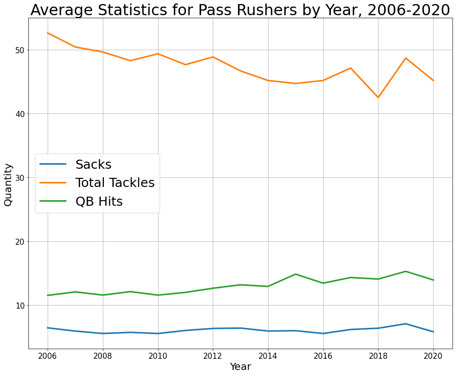

```python
yearly_avg_plot = yearly_avg.plot.line(figsize=(15, 12), fontsize=15, linewidth=3.0)
yearly_avg_plot.set_xlabel('Year', fontsize=20)
yearly_avg_plot.set_ylabel('Quantity', fontsize=20)
yearly_avg_plot.set_title("Average Statistics for Pass Rushers by Year, 2006-2020", fontsize = 30)
yearly_avg_plot.legend(loc=6, prop={'size': 25})
yearly_avg_plot.grid()
```

### Step 3: Observations based on Player Age

Finally, we want to see how our variables differ based on the age of the player. NFL teams want to have players "in their prime." But when exactly is that? At what age do pass rushers hit their peak on average? Here we hope to find out. We will start by plotting averages by age like above, and see what we can gain from the visualization.

#### a) Isolate necessarty data

For this section we only need the data regarding our independent variable (player age), and our dependent variables (Sacks, tackles, and QB hits). We may want to look at whether or not a team made the pro bowl, so we will include those variables as well.

```python
age_stats = player_stats[['Age','Sk','Tackles_Comb','Tackles_QBHits','made_pro_bowl']]
```

```python
columns = ['Sk','Tackles_Comb','Tackles_QBHits']
column_names = ["Sacks","Total Tackles","QB Hits"]
```

#### b) Reformat data to prepare for plotting

Just like part b) from above, we need to first group the data by our independent variable, this time age, then calculate the mean of each column for each year.

```python
age_avg =  age_stats[['Age','Sk','Tackles_Comb','Tackles_QBHits']].groupby('Age').mean()
```

#### c) Plot data

Just like above: To plot a line plot on a dataframe using all the columns, we can simply call **plot.line** on the object itself. Set the title and axes to the proper size and descriptions. Add a legend to the plot to help identify the lines.

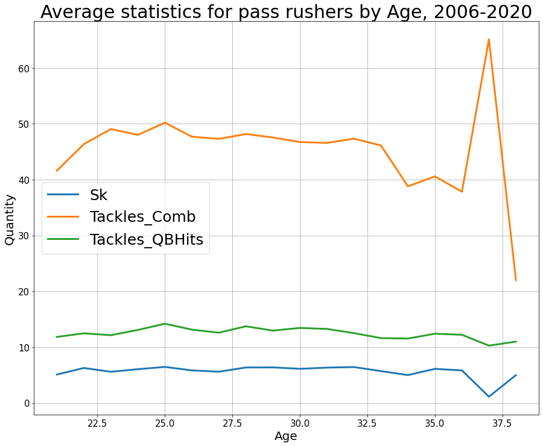

```python
age_avg_plot = age_avg.plot.line(figsize=(15, 12), fontsize=15, linewidth=3.0)
age_avg_plot.set_xlabel('Age', fontsize=20)
age_avg_plot.set_ylabel('Quantity', fontsize=20)
age_avg_plot.set_title("Average statistics for pass rushers by Age, 2006-2020", fontsize = 30)
age_avg_plot.legend(loc=6, prop={'size': 25})
age_avg_plot.grid()
```

#### b) Reformat data to prepare for plotting

As the line plots of averages did not tell us enough about the trends by age, we will look instead to the distribution. Additionally, it might be useful to differentiate between the average NFL player and the top. It is possible that the best players in the league have their best seasons earlier or later than average. Therefore, for this batch of plots, we will separate the points by whether or not the player was in the pro bowl. This time, to measure distribution, we will use box plots.

First, we group the data into pro-bowl and not pro-bowl players. We will further split into the different variables during the plotting process. As we will be making plots side by side, we need to make sure the axes for the plots are equal. To do this we find and store the max value for each variable to use as the max of the y-axis.

```python
age_data = age_stats.dropna().groupby('made_pro_bowl')

y_lim = [int(player_stats[cur].max() + 1) for cur in columns]
```

#### c) Plot data

For this plot, we are going to produce a series of subplots- three rows of two columns. The rows are for each of the dependent variables. The left column shows the statistics for players not in the pro bowl, the the right column is for pro bowlers. Additionally, it would be useful to see how Chase Young stacks up against other players in his age group. Chase Young's data will be represented by a red point on top of the box plot.

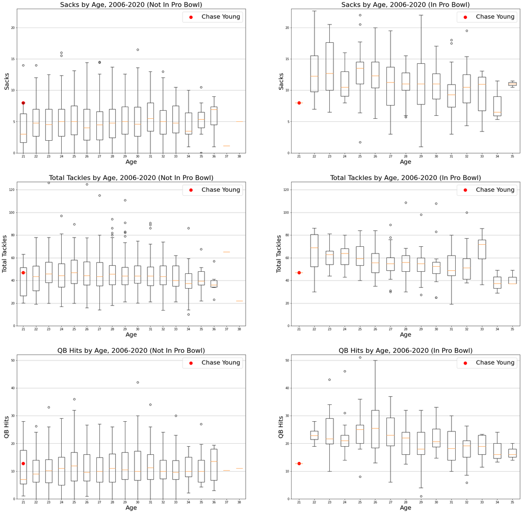

```python
# Six plots: three rows, two columns
fig, ax = plt.subplots(3,2,figsize=(30,30))

# For each of the three dependent variables, create two box plots
for cur_stat in range(3):
    cur_col = columns[cur_stat]
    cur_name = column_names[cur_stat]

    # Iterate through the data split by pro_bowl appearance to make the two plots
    for pro_bowl, data in age_data:
        X = data['Age']
        Y = data[cur_col]
        in_pb = "In Pro Bowl" if pro_bowl == 1 else "Not In Pro Bowl"
        title = cur_name + " by Age, 2006-2020 (" + in_pb + ")"

        # A mini step b)
        # Format each of the two subFrames to group the data by age, then turn the
        # grouped columns into lists of lists for access by the boxplot function
        to_plot = pd.DataFrame({"X":X,"Y":Y}).groupby("X")
        positions = []
        values = []
        for cur_x, cur_y in to_plot:
            positions.append(cur_x)
            values.append(cur_y['Y'])

        # Create the plots
        ax[cur_stat,pro_bowl].boxplot(values, positions=positions)
        ax[cur_stat,pro_bowl].set_ylim([0,y_lim[cur_stat]])
        ax[cur_stat,pro_bowl].set_xlabel("Age",fontsize=20)
        ax[cur_stat,pro_bowl].set_ylabel(cur_name,fontsize=20)
        ax[cur_stat,pro_bowl].set_title(title,fontsize=22)
        ax[cur_stat,pro_bowl].grid(axis="y")

        # Add a point to represent Chase Young's statistics
        X_CY = chase_young['Age']
        Y_CY = chase_young[cur_col]
        ax[cur_stat,pro_bowl].scatter(X_CY,Y_CY,c='red',label="Chase Young",s=100)
        ax[cur_stat,pro_bowl].legend(loc='upper right',fontsize=20)
```

#### d) Analysis

In the next section we will learn how to make predictions using the data to see what the numbers think are in store for Chase Young's career.

## Part 3: Making Predictions

Now that we have developed an understanding of that data we have available to us, it is time to start making predictions from it. There are two types of predictors we will be looking at: regression analysis and classification. Regression analysis takes data over a continuous independent variable and finds a predictive trend to estimate an output. Classification prediction systems look at inputted estimators and return which category your input *should* fall under.

To predict how successful Chase Young's career will be, we want to be able to predict what his stats will look at by age 25, the standard peak season for pass rushers (regression). We then want to make predictors for what an all-pro and pro-bowl season looks like (classification). Finally, we will input Chase Young's predicted stats into the pro-bowl and all-pro predictors to see if his stats should be good enough to earn those titles.

### Step 1: Regression Analysis

Here we will try to learn what Chase Young's stats will be in each of the three major categories based on age: sacks, QB hits, and tackles. We learned above that making the pro bowl changes the spread of data, so we will include that statistic in our regression model. As recieving an award suggests a different statistic for that season, we can also assume making the all-pro team is also a valid predictor. However, as we want to use these stats to determine whether or not Chase Young will earn these awards in his age 25 season, we cannot use them on a year-by-year basis. Instead, we need to modify them to hold whether or not the player ever made the pro bowl or all pro.

We make that adjustment here:

```python
ever_won = player_stats
group_by_players = player_stats.groupby('Player')
for i in range(len(ever_won)):
    ever_won.at[i, 'made_pro_bowl'] = 1 if group_by_players.get_group(
        ever_won.at[i, 'Player'])['made_pro_bowl'].unique().mean() > 0 else 0
    ever_won.at[i, 'made_all_pro'] = 1 if group_by_players.get_group(
        ever_won.at[i, 'Player'])['made_all_pro'].unique().mean() > 0 else 0
```

As we learned, the peak season for a player, on average, is at age 25, with stats decreasing on average after that year. Therefore, we will only use statistics from players up to age 25 for our regression model.

```python
under_25 = ever_won.loc[player_stats['Age'] <= 25].reset_index(drop=True)
```

To prepare the estimators for the regression model, we need to add the proper columns to the dataframe. We need columns for:

- Age
- Made the pro bowl
- Made the all-pro team
- Age * made the pro bowl
- Age * made the all-pro team

```python
age_pro_bowl = []
age_all_pro = []

for i in range(len(under_25)):
    age_pro_bowl.append(under_25.at[i, 'Age'] * under_25.at[i, 'made_pro_bowl'])
    age_all_pro.append(under_25.at[i, 'Age'] * under_25.at[i, 'made_all_pro'])
```

```python
under_25['age*pro_bowl'] = age_pro_bowl
under_25['age*all_pro'] = age_all_pro
under_25.head()
```

|  | Player | Age | Pos | Sk | Tackles_Comb | Tackles_QBHits | year | made_pro_bowl | made_all_pro | age*pro_bowl | age*all_pro |
| --- | --- | --- | --- | --- | --- | --- | --- | --- | --- | --- | --- |
| 0 | Jared Allen | 24 | RDE | 7.500000 | 76.0 | 15.000000 | 2006 | 1 | 1 | 24 | 24 |
| 1 | Terrell Suggs | 24 | RDE | 9.500000 | 65.0 | 15.000000 | 2006 | 1 | 1 | 24 | 24 |
| 2 | Mathias Kiwanuka | 23 | RDE | 4.000000 | 53.0 | 9.000000 | 2006 | 0 | 0 | 0 | 0 |
| 3 | Victor Adeyanju | 23 | RDE | 1.333333 | 56.0 | 2.666667 | 2006 | 0 | 0 | 0 | 0 |
| 4 | Melvin Oliver | 23 | RDE | 1.000000 | 43.0 | 3.000000 | 2006 | 0 | 0 | 0 | 0 |

Now that we have all the data we want, we separate into dependent and independent variables.

```python
Tackles = under_25['Tackles_Comb'].tolist()
Sacks = under_25['Sk'].tolist()
QB_hits = under_25['Tackles_QBHits'].tolist()
```

```python
reg_ind = under_25[['Age','made_pro_bowl','made_all_pro','age*pro_bowl','age*all_pro']].values.tolist()
```

Once again, let's separate Chase Young's data so we can see how the predictions expect him to perform.

```python
CY_reg_table = under_25.loc[under_25['Player'] == 'Chase Young'].reset_index(drop=True)

CY_Tackles = CY_reg_table['Tackles_Comb'].tolist()[0]
CY_Sacks = CY_reg_table['Sk'].tolist()[0]
CY_QB_hits = CY_reg_table['Tackles_QBHits'].tolist()[0]

CY_ind = CY_reg_table[['Age','made_pro_bowl','made_all_pro','age*pro_bowl','age*all_pro']].values.tolist()
```

Now, let's create a new input for Chase Young at age 25, so we can see what the predictors believe is in store for the player in the future.

We will change his age to 25, and in turn, his age*pro_bowl score.

```python
CY_predictor_table = CY_reg_table
CY_predictor_table.at[0, 'Age'] = 25
CY_predictor_table.at[0, 'age*pro_bowl'] = 25

CY_25_predictor = CY_predictor_table[['Age','made_pro_bowl','made_all_pro',
                                      'age*pro_bowl','age*all_pro']].values.tolist()
```

#### Regression: Tackles

First, we will create a linear regression for tackles. We create a linear regression object and fit it using our independent variables, and our tackles list.

```python
tackles_reg = linear_model.LinearRegression().fit(reg_ind, Tackles)
```

```python
print('coefficient of determination:', tackles_reg.score(reg_ind, Tackles))
print()
print('intercept:', tackles_reg.intercept_)
print()
print('slope:', tackles_reg.coef_)
```

```
coefficient of determination: 0.14805898760511704

intercept: 16.683841745716144

slope: [ 1.17771023  9.71514942 -8.60691919 -0.00980983  0.56262379]
```

#### Making a tackles prediction for Chase Young

We are now going to use this model to predict Chase Young's tackles for his age 25 season. First we will find the residual value between his actual age 21 season to what the model predicted. We will then find what the model predicts for an age 25 season, then add the residual to that prediction.

```python
CY_tackles_pred = tackles_reg.predict(CY_ind)[0]
CY_tackles_residual = CY_Tackles - CY_tackles_pred
print("Chase Young's residual Tackle score:", CY_tackles_residual)
```

```
Chase Young's residual Tackle score: -3.9915661154331445
```

```python
CY_25_pred_tackles = tackles_reg.predict(CY_25_predictor)[0] + CY_tackles_residual
print("Chase Young's predicted number of tackles at age 25:", CY_25_pred_tackles)
```

```
Chase Young's predicted number of tackles at age 25: 51.60493491067514
```

Interestingly, our model expected Chase Young to have had more tackles in his rookie season than he actually had. This is likely because of his low number of tackles relative to other pro bowlers. Our predicted number of tackles for him reflects this lower number by subtracting its suggested number of tackles for a 25 year old pro bowler by Chase Young's residual value.

#### Regression: Sacks

Now we move on to predicting sacks. We will preform the exact same steps as above, with our Sacks list functioning as the new dependent variable.

```python
sacks_reg = linear_model.LinearRegression().fit(reg_ind, Sacks)
```

```python
print('coefficient of determination:', sacks_reg.score(reg_ind, Sacks))
print()
print('intercept:', sacks_reg.intercept_)
print()
print('slope:', sacks_reg.coef_)
```

```
coefficient of determination: 0.3723257743189399

intercept: -0.19967513969519324

slope: [ 0.18833866 -0.55727808  1.27654415  0.19493925  0.05981189]
```

While a better score than the tackles, 0.37 is a long way from the perfect 1.0

#### Making a sacks prediction for Chase Young

We are now going to use this model to predict Chase Young's sacks for his age 25 season. First we will find the residual value between his actual age 21 season to what the model predicted. We will then find what the model predicts for an age 25 season, then add the residual to that prediction.

```python
CY_sacks_pred = sacks_reg.predict(CY_ind)[0]
CY_sacks_residual = CY_Sacks - CY_sacks_pred
print("Chase Young's residual Sack score:", CY_sacks_residual)
```

```
Chase Young's residual Sack score: 0.7081171374222635
```

```python
CY_25_pred_sacks = sacks_reg.predict(CY_25_predictor)[0] + CY_sacks_residual
print("Chase Young's predicted number of sacks at age 25:", CY_25_pred_sacks)
```

```
Chase Young's predicted number of sacks at age 25: 9.53311163492432
```

#### Regression: QB Hits

Our final regression analysis is for QB hits. Same steps as before, with QB hits as the current dependent variable.

```python
QB_hits_reg = linear_model.LinearRegression().fit(reg_ind, QB_hits)
```

```python
print('coefficient of determination:', QB_hits_reg.score(reg_ind, QB_hits))
print()
print('intercept:', QB_hits_reg.intercept_)
print()
print('slope:', QB_hits_reg.coef_)
```

```
coefficient of determination: 0.2809623874492094

intercept: -3.586187055685551

slope: [ 0.5736033   0.66094196 -8.47114073  0.30403873  0.46101599]
```

Again, not a very strong score. Still, better than the tackles predictor.

#### Making a QB hits prediction for Chase Young

We are now going to use this model to predict Chase Young's QB hits for his age 25 season. First we will find the residual value between his actual age 21 season to what the model predicted. We will then find what the model predicts for an age 25 season, then add the residual to that prediction.

```python
CY_QB_hits_pred = QB_hits_reg.predict(CY_ind)[0]
CY_QB_hits_residual = CY_QB_hits - CY_QB_hits_pred
print("Chase Young's residual QB Hits score:", CY_QB_hits_residual)
```

```
Chase Young's residual QB Hits score: -2.7052375173220486
```

```python
CY_25_pred_QB_hits = QB_hits_reg.predict(CY_25_predictor)[0] + CY_QB_hits_residual
print("Chase Young's predicted number of QB hits at age 25:", CY_25_pred_QB_hits)
```

```
Chase Young's predicted number of QB hits at age 25: 16.310568116006216
```

While Chase Young exceeded prediction on sacks, he was below on QB hits. This is not surprising when looking back at the plots. Chase Young fared the worst relative to other pro bowlers in this category.

#### Create a stat line for 25 year old Chase Young

Here we put all the pieces together and recreate our Chase Young dataFrame with our predicted stats. According to our models, this is what we expect Chase Young's best season to look like. In the next step, we will use classification analysis to see if these numbers should be good enough to make the pro bowl, and even the all-pro team.

```python
CY_25 = chase_young
CY_25['Age'] = 25
CY_25['Sk'] = CY_25_pred_sacks
CY_25['Tackles_QBHits'] = CY_25_pred_QB_hits
CY_25['Tackles_Comb'] = CY_25_pred_tackles
```

### Step 2: Classification Analysis

In this step, we will use decision trees to determine whether or not a given player should be in the pro bowl and on the all-pro team based on their stats for the given season. Once these algorithms are created, we can use them to determine what honors Chase Young's age 25 season should earn.

First, we create our table to use for fitting our decision tree. We need to remove Chase Young from the analysis, as we want to predict him later. If the algorithm already knows the outcome of his exact numbers, then our test would be irrelevant. Additionally, the fitting function for decision trees does not handle missing data well, so we will remove rows that have missing data from the predictor.

```python
classification = player_stats.loc[player_stats['Player'] != 'Chase Young'].dropna()
```

Next, we set our dependent variables...

```python
pro_bowl = pd.Categorical.from_codes(classification['made_pro_bowl'], ['missed pro bowl','made pro bowl'])
all_pro = pd.Categorical.from_codes(classification['made_all_pro'], ['missed all pro','made all pro'])
```

...and our independent variables.

```python
ind = classification[['Sk','Tackles_Comb','Tackles_QBHits']].values.tolist()
```

#### Decision Tree for Pro Bowl Appearences

First, we create a decision tree model for whether or not a player should make the pro bowl based on the number of sacks, tackles and qb hits they earned in a season.

```python
dt_pb = DecisionTreeClassifier()
```

Here we split our data into train and test data. We use the train data to fit our decision tree, and we use the test data to determine the accuracy of our fitted tree.

```python
ind_train, ind_test, dep_train, dep_test = ms.train_test_split(ind, pro_bowl,stratify=pro_bowl)
```

```python
dt_pb.fit(ind_train, dep_train)
predicted_pro_bowl = dt_pb.predict(ind_test)
print("Accuracy score for Pro Bowl Predictor: ", 100 * met.accuracy_score(dep_test, predicted_pro_bowl))
```

```
Accuracy score for Pro Bowl Predictor:  66.5625
```

According to the accuracy score, the decision tree could only determine whether or not a player made the pro bowl correctly 66.56% of the time, which is far from perfect. Part of the reason this model is not too accurate could be the lack of independent variables. Our table originally held many more data points than we explored in this tutorial, and if we perhaps used more of those to make the prediction, it could have been more accurate. Additionally, pro-bowl selection is somewhat biased. A large weight of pro-bowl selection is taken by fan voting, which potentially makes earning a spot on the pro bowl roster a popularity contest rather than a simple check of the statistics.

For more on how the pro bowl selects its players, click [here.](https://entertainment.howstuffworks.com/nfl-pro-bowl1.htm)

#### Decision Tree for All-Pro Appearences

Next, we do the same to determine the probability a player makes the all-pro team.

```python
dt_ap = DecisionTreeClassifier()
```

```python
ind_train, ind_test, dep_train, dep_test = ms.train_test_split(ind, all_pro,stratify=all_pro)
```

```python
dt_ap.fit(ind_train, dep_train)
predicted_all_pro = dt_ap.predict(ind_test)
print("Accuracy score for All Pro Predictor: ", 100 * met.accuracy_score(dep_test, predicted_all_pro))
```

```
Accuracy score for All Pro Predictor:  77.5
```

Our decision tree for all-pro prediction was significantly more accurate than the pro bowl's. There are two possible factors for this occurance. First, unlike the pro bowl, fan voting has no influence over the selection of players to earn this honor. Instead, it falls to a team of analysts to make the designations. Another factor could include the fact that there are so few all-pro players in our sample. As shown below, only about 18% of our samples earned that honor for their season. Because the algorithm had so few all-pro players to test on, it is possible that it is biased.

For more on how all-pro players are selected, click [here.](https://en.wikipedia.org/wiki/2020_All-Pro_Team)

```python
print("Percentage of all-pro seasons in our sample: ",
      100 * len(classification.loc[classification['made_all_pro'] == 1]) / len(classification))
```

```
Percentage of all-pro seasons in our sample:  17.996870109546165
```

#### Should Chase Young have been in the Pro Bowl? Should he have been and All Pro?

Before we reach our final test, it might be useful to see what honors our prediction algorithms believe Chase Young *should have* earned in his rookie season. As we noticed in our box plots, Chase Young's stats were higher than most players who missed the pro bowl, but lower than many who made the cut. Let's see if our algorithm believes he actually should have earned his title. For an added bonus, we will see if he might have been accepted to the all-pro team as well.

```python
CY_pro_bowl = chase_young['made_pro_bowl']
CY_all_pro = chase_young['made_all_pro']
CY_ind = chase_young[['Sk','Tackles_Comb','Tackles_QBHits']].values.tolist()
```

```python
print("Algorithm's prediction for whether Chase Young should've made the pro bowl his rookie season: ",
      dt_pb.predict(CY_ind)[0])
```

```
Algorithm's prediction for whether Chase Young should've made the pro bowl his rookie season:  made pro bowl
```

```python
print("Algorithm's prediction for whether Chase Young should've been an all-pro his rookie season: ",
      dt_ap.predict(CY_ind)[0])
```

```
Algorithm's prediction for whether Chase Young should've been an all-pro his rookie season:  missed all pro
```

To what should have been a surprise to no one, Chase Young should not have been an all-pro player his rookie year. However, Washington fans can breathe a sigh of relief knowing that, according to our algorithm, Chase Young did in fact have the stats necessary to make the pro bowl.

#### Should we expect Chase Young to be in the Pro Bowl/All Pro in his age 25 season?

Here it is: the grand finale. Our entire tutorial has been building to this moment. We have seen the trends and made predictions, both catagorical and regressive. All our pieces are in place. We have created our best guess at what Chase Young's best season could look like. We have created algorithms made to take in a player's season and spit out what honors they should earn. Now, lets see what our algorithms have to say about Chase Young's "best year."

```python
CY_25_pro_bowl = CY_25['made_pro_bowl']
CY_25_all_pro = CY_25['made_all_pro']
CY_25_ind = CY_25[['Sk','Tackles_Comb','Tackles_QBHits']].values.tolist()
```

```python
print("Algorithm's prediction for whether Chase Young should make the pro bowl his age 25 season: ",
      dt_pb.predict(CY_25_ind)[0])
```

```
Algorithm's prediction for whether Chase Young should make the pro bowl his age 25 season:  made pro bowl
```

```python
print("Algorithm's prediction for whether Chase Young should be an all-pro his age 25 season: ",
      dt_ap.predict(CY_25_ind)[0])
```

```
Algorithm's prediction for whether Chase Young should be an all-pro his age 25 season:  missed all pro
```

Our models predict that Chase Young should make the pro bowl in his best season. This makes logical sense, as he already earned a pro bowl nod in a worse statistical season. Unfortunately, our model does not see Chase Young making the all-pro team, even in his (projected) best season. Therefore, we fail to reject our null hypothesis that Chase Young will never be an all-pro player.

## Conclusion

In this tutorial, we learned how to scrape data from an HTML page. We learned how to organize and standardize a data table. We found different ways to visualize data through plotting. Through the plots, we developed a better understanding of data analysis. Finally, we created linear regression and categorical predictive models, and applied them to test our hypothesis.

But what did we learn about our subject in all these tests? Through our several predictive algorithms, we managed to make a hypothetical "best season" for Washington NFL superstar Chase Young, and then test that best season in our *"will he be an all-pro?"* predictive algorithm. Unfortunately for all Washington fans reading this tutorial, our best season for Young did not make the cut for all-pro honors. If our tests are to be believed, then my worst fears have been realized: Chase Young is an overhyped player, given high projections more for his charisma and high draft position than for the actual numbers he racked up on the field.

However, there are many reasons to doubt the conclusions we made. First, we look at our algorithms themselves. Unfortunately, they were not very accurate. Our regression tests in particular failed to have a coefficient of determination above even 0.5. That means we should have very little faith in the numbers we made for him. Additionally, because we had so few all-pro seasons to help fit our categorical algorithm, it is possible it also struggled with making accurate predictions. As this is a data science tutorial more than anything, we chose to focus on a very narrow set of statistics to explore. This is a primary reason why our predictive algorithms were so weak.

If we were to return to further analyze and refine our algorithms, we would add many more predictors. These include several of the statistics we left behind in our initial dataframe, including types of tackles and fumbles. It is also possible that team has an effect. Maybe a successful team brings more attention to its players, and therefore makes them more likely to earn honors. A final category I would consider adding was mentioned earlier: draft position. It would be reasonable to assume that a 1st round player would take a bigger step forward by their age 25 season than someone who was never drafted. An [article](https://www.rockmnation.com/2019/2/21/18233383/first-rounders-dominate-the-ranks-of-nfl-all-pro-selections) online shows that the vast majority of all pro players were drafted in the first round.

However, no matter the refinement, we would never be able to create a completely accurate prediction. Much of what gets a player on the pro-bowl or all-pro team lies outside of statistics. Pro bowl selection is largely voted on by the fans, making popularity a big factor, drowning out raw numbers. While fans do not have a hand in all-pro selection, those honors are still bestowed by human beings rather than a machine learning algorithm, allowing subjective thought to enter the equation.

But it is not only how players are chosen that adds a level of subjectivity to the equation. An important factor includes intangibles; leadership, charisma, hustle. Players can be great not just by their own individual numbers, but by how they bring out the best in their teammates. It is in these intangibles that Washington fans can have hope for a legendary future for Chase Young. He is already a proven leader. He was already [named team captain in his rookie season](https://www.nbcsports.com/washington/football-team/chase-youngs-attitude-and-performance-led-ron-rivera-name-him-captain), taking a leadership position over men nearly twice his age. He has charisma in spades; [watch](https://www.youtube.com/watch?v=noW6EUEUe0c) his celebrations on the sidelines, or take note of his spectacular nickname, "The Predator." And there are few players with the hustle of Chase Young. Take [this play](https://www.espn.com/nfl/story/_/id/30366225/chase-young-forces-joe-burrow-fumble-goal-line) against the Cincinnati Bengals. In terms of the stats we were observing, this is nothing more than one tackle. However, in the context of the game, it was monumental. Young managed to run across the entire field to stop a one yard run on fourth and goal, forcing a fumble and preventing a touchdown. This was a game changing play, even though all it did was tick his tackle count up a notch. Plays like these are what give Young his claim to fame.

Overall, while Washington fans reading this tutorial may be disappointed that Young's numbers have not stood out so far, there is still hope that he may one day become an all-time great. But, as our tutorial shows, a Washington fan should not be more than cautiously optimistic, and should never get carried away by the hype.